# Importing all the Libraries

```python
import pandas as pd
import numpy as np
import matplotlib.pyplot as plt
import seaborn as sns
```

```python
# reading the dataset using read_csv method
df = pd.read_csv('housing.csv')
```

```python
df
```

|  | longitude | latitude | housing_median_age | total_rooms | total_bedrooms | population | households | median_income | median_house_value | ocean_proximity |
| --- | --- | --- | --- | --- | --- | --- | --- | --- | --- | --- |
| 0 | -122.23 | 37.88 | 41.0 | 880.0 | 129.0 | 322.0 | 126.0 | 8.3252 | 452600.0 | NEAR BAY |
| 1 | -122.22 | 37.86 | 21.0 | 7099.0 | 1106.0 | 2401.0 | 1138.0 | 8.3014 | 358500.0 | NEAR BAY |
| 2 | -122.24 | 37.85 | 52.0 | 1467.0 | 190.0 | 496.0 | 177.0 | 7.2574 | 352100.0 | NEAR BAY |
| 3 | -122.25 | 37.85 | 52.0 | 1274.0 | 235.0 | 558.0 | 219.0 | 5.6431 | 341300.0 | NEAR BAY |
| 4 | -122.25 | 37.85 | 52.0 | 1627.0 | 280.0 | 565.0 | 259.0 | 3.8462 | 342200.0 | NEAR BAY |
| ... | ... | ... | ... | ... | ... | ... | ... | ... | ... | ... |
| 20635 | -121.09 | 39.48 | 25.0 | 1665.0 | 374.0 | 845.0 | 330.0 | 1.5603 | 78100.0 | INLAND |
| 20636 | -121.21 | 39.49 | 18.0 | 697.0 | 150.0 | 356.0 | 114.0 | 2.5568 | 77100.0 | INLAND |
| 20637 | -121.22 | 39.43 | 17.0 | 2254.0 | 485.0 | 1007.0 | 433.0 | 1.7000 | 92300.0 | INLAND |
| 20638 | -121.32 | 39.43 | 18.0 | 1860.0 | 409.0 | 741.0 | 349.0 | 1.8672 | 84700.0 | INLAND |
| 20639 | -121.24 | 39.37 | 16.0 | 2785.0 | 616.0 | 1387.0 | 530.0 | 2.3886 | 89400.0 | INLAND |

20640 rows × 10 columns

```python
# .info() is used to display the summary of the dataset
df.info()
```

```
<class 'pandas.core.frame.DataFrame'>
RangeIndex: 20640 entries, 0 to 20639
Data columns (total 10 columns):
 #   Column              Non-Null Count  Dtype
---  ------              --------------  -----
 0   longitude           20640 non-null  float64
 1   latitude            20640 non-null  float64
 2   housing_median_age  20640 non-null  float64
 3   total_rooms         20640 non-null  float64
 4   total_bedrooms      20433 non-null  float64
 5   population          20640 non-null  float64
 6   households          20640 non-null  float64
 7   median_income       20640 non-null  float64
 8   median_house_value  20640 non-null  float64
 9   ocean_proximity     20640 non-null  object
dtypes: float64(9), object(1)
memory usage: 1.6+ MB
```

```python
# to display the shape of the dataframe
df.shape
```

```
(20640, 10)
```

```python
# printing the column names
df.columns
```

```
Index(['longitude', 'latitude', 'housing_median_age', 'total_rooms',
       'total_bedrooms', 'population', 'households', 'median_income',
       'median_house_value', 'ocean_proximity'],
      dtype='object')
```

As we have total 10 columns, out of this there are 9 inputs (features) and 1 output (target) variables

```python
# display the target variable
df['median_house_value']
```

|  | median_house_value |
| --- | --- |
| 0 | 452600.0 |
| 1 | 358500.0 |
| 2 | 352100.0 |
| 3 | 341300.0 |
| 4 | 342200.0 |
| ... | ... |
| 20635 | 78100.0 |
| 20636 | 77100.0 |
| 20637 | 92300.0 |
| 20638 | 84700.0 |
| 20639 | 89400.0 |

20640 rows × 1 columns

**dtype:** float64

Combination of rows and columns is knowns as a dataframe (tabular data).  
Single column is known as a series.

```python
# checking the data type of both dataframe and series
# print(type(df))
# or
type(df)
```

```
pandas.core.frame.DataFrame
def __init__(data=None, index: Axes | None=None, columns: Axes | None=None, dtype: Dtype | None=None, copy: bool | None=None) -> None
```

[output not shown]

[output cut: 76 more lines]

[output not shown]

```python
type(df['median_house_value'])
```

```
pandas.core.series.Series
def __init__(data=None, index=None, dtype: Dtype | None=None, name=None, copy: bool | None=None, fastpath: bool=False) -> None
```

[output not shown]

[output cut: 39 more lines]

[output not shown]

```python
# display top 5 rows using .head()
df.head()
```

|  | longitude | latitude | housing_median_age | total_rooms | total_bedrooms | population | households | median_income | median_house_value | ocean_proximity |
| --- | --- | --- | --- | --- | --- | --- | --- | --- | --- | --- |
| 0 | -122.23 | 37.88 | 41.0 | 880.0 | 129.0 | 322.0 | 126.0 | 8.3252 | 452600.0 | NEAR BAY |
| 1 | -122.22 | 37.86 | 21.0 | 7099.0 | 1106.0 | 2401.0 | 1138.0 | 8.3014 | 358500.0 | NEAR BAY |
| 2 | -122.24 | 37.85 | 52.0 | 1467.0 | 190.0 | 496.0 | 177.0 | 7.2574 | 352100.0 | NEAR BAY |
| 3 | -122.25 | 37.85 | 52.0 | 1274.0 | 235.0 | 558.0 | 219.0 | 5.6431 | 341300.0 | NEAR BAY |
| 4 | -122.25 | 37.85 | 52.0 | 1627.0 | 280.0 | 565.0 | 259.0 | 3.8462 | 342200.0 | NEAR BAY |

```python
# display bottom 5 rows using .tail()
df.tail()
```

|  | longitude | latitude | housing_median_age | total_rooms | total_bedrooms | population | households | median_income | median_house_value | ocean_proximity |
| --- | --- | --- | --- | --- | --- | --- | --- | --- | --- | --- |
| 20635 | -121.09 | 39.48 | 25.0 | 1665.0 | 374.0 | 845.0 | 330.0 | 1.5603 | 78100.0 | INLAND |
| 20636 | -121.21 | 39.49 | 18.0 | 697.0 | 150.0 | 356.0 | 114.0 | 2.5568 | 77100.0 | INLAND |
| 20637 | -121.22 | 39.43 | 17.0 | 2254.0 | 485.0 | 1007.0 | 433.0 | 1.7000 | 92300.0 | INLAND |
| 20638 | -121.32 | 39.43 | 18.0 | 1860.0 | 409.0 | 741.0 | 349.0 | 1.8672 | 84700.0 | INLAND |
| 20639 | -121.24 | 39.37 | 16.0 | 2785.0 | 616.0 | 1387.0 | 530.0 | 2.3886 | 89400.0 | INLAND |

```python
# we can even display a number of rows by providing a value inside .head() and .tail()
df.head(2)
```

|  | longitude | latitude | housing_median_age | total_rooms | total_bedrooms | population | households | median_income | median_house_value | ocean_proximity |
| --- | --- | --- | --- | --- | --- | --- | --- | --- | --- | --- |
| 0 | -122.23 | 37.88 | 41.0 | 880.0 | 129.0 | 322.0 | 126.0 | 8.3252 | 452600.0 | NEAR BAY |
| 1 | -122.22 | 37.86 | 21.0 | 7099.0 | 1106.0 | 2401.0 | 1138.0 | 8.3014 | 358500.0 | NEAR BAY |

```python
# Displaying the categorical column
df['ocean_proximity'].head()
```

|  | ocean_proximity |
| --- | --- |
| 0 | NEAR BAY |
| 1 | NEAR BAY |
| 2 | NEAR BAY |
| 3 | NEAR BAY |
| 4 | NEAR BAY |

**dtype:** object

```python
# statistical summary - this excludes the caterogical column's summary
df.describe()
```

|  | longitude | latitude | housing_median_age | total_rooms | total_bedrooms | population | households | median_income | median_house_value |
| --- | --- | --- | --- | --- | --- | --- | --- | --- | --- |
| count | 20640.000000 | 20640.000000 | 20640.000000 | 20640.000000 | 20433.000000 | 20640.000000 | 20640.000000 | 20640.000000 | 20640.000000 |
| mean | -119.569704 | 35.631861 | 28.639486 | 2635.763081 | 537.870553 | 1425.476744 | 499.539680 | 3.870671 | 206855.816909 |
| std | 2.003532 | 2.135952 | 12.585558 | 2181.615252 | 421.385070 | 1132.462122 | 382.329753 | 1.899822 | 115395.615874 |
| min | -124.350000 | 32.540000 | 1.000000 | 2.000000 | 1.000000 | 3.000000 | 1.000000 | 0.499900 | 14999.000000 |
| 25% | -121.800000 | 33.930000 | 18.000000 | 1447.750000 | 296.000000 | 787.000000 | 280.000000 | 2.563400 | 119600.000000 |
| 50% | -118.490000 | 34.260000 | 29.000000 | 2127.000000 | 435.000000 | 1166.000000 | 409.000000 | 3.534800 | 179700.000000 |
| 75% | -118.010000 | 37.710000 | 37.000000 | 3148.000000 | 647.000000 | 1725.000000 | 605.000000 | 4.743250 | 264725.000000 |
| max | -114.310000 | 41.950000 | 52.000000 | 39320.000000 | 6445.000000 | 35682.000000 | 6082.000000 | 15.000100 | 500001.000000 |

1. Convert the categorical variables into numeric.
2. Find correlation between the columns.

```python
# Correlation of numeric columns
df.head()
```

|  | longitude | latitude | housing_median_age | total_rooms | total_bedrooms | population | households | median_income | median_house_value | ocean_proximity |
| --- | --- | --- | --- | --- | --- | --- | --- | --- | --- | --- |
| 0 | -122.23 | 37.88 | 41.0 | 880.0 | 129.0 | 322.0 | 126.0 | 8.3252 | 452600.0 | NEAR BAY |
| 1 | -122.22 | 37.86 | 21.0 | 7099.0 | 1106.0 | 2401.0 | 1138.0 | 8.3014 | 358500.0 | NEAR BAY |
| 2 | -122.24 | 37.85 | 52.0 | 1467.0 | 190.0 | 496.0 | 177.0 | 7.2574 | 352100.0 | NEAR BAY |
| 3 | -122.25 | 37.85 | 52.0 | 1274.0 | 235.0 | 558.0 | 219.0 | 5.6431 | 341300.0 | NEAR BAY |
| 4 | -122.25 | 37.85 | 52.0 | 1627.0 | 280.0 | 565.0 | 259.0 | 3.8462 | 342200.0 | NEAR BAY |

```python
# df.drop() - by defualt it removes the rows
# axis = 1 - in pandas it refers to columns
# axis = 0 - in pandas it refers to rows
# axis defines that the data is in 2D format

df_numeric = df.drop('ocean_proximity', axis=1)
```

```python
df_numeric.head()
```

|  | longitude | latitude | housing_median_age | total_rooms | total_bedrooms | population | households | median_income | median_house_value |
| --- | --- | --- | --- | --- | --- | --- | --- | --- | --- |
| 0 | -122.23 | 37.88 | 41.0 | 880.0 | 129.0 | 322.0 | 126.0 | 8.3252 | 452600.0 |
| 1 | -122.22 | 37.86 | 21.0 | 7099.0 | 1106.0 | 2401.0 | 1138.0 | 8.3014 | 358500.0 |
| 2 | -122.24 | 37.85 | 52.0 | 1467.0 | 190.0 | 496.0 | 177.0 | 7.2574 | 352100.0 |
| 3 | -122.25 | 37.85 | 52.0 | 1274.0 | 235.0 | 558.0 | 219.0 | 5.6431 | 341300.0 |
| 4 | -122.25 | 37.85 | 52.0 | 1627.0 | 280.0 | 565.0 | 259.0 | 3.8462 | 342200.0 |

```python
df_numeric.corr()
```

|  | longitude | latitude | housing_median_age | total_rooms | total_bedrooms | population | households | median_income | median_house_value |
| --- | --- | --- | --- | --- | --- | --- | --- | --- | --- |
| longitude | 1.000000 | -0.924664 | -0.108197 | 0.044568 | 0.069608 | 0.099773 | 0.055310 | -0.015176 | -0.045967 |
| latitude | -0.924664 | 1.000000 | 0.011173 | -0.036100 | -0.066983 | -0.108785 | -0.071035 | -0.079809 | -0.144160 |
| housing_median_age | -0.108197 | 0.011173 | 1.000000 | -0.361262 | -0.320451 | -0.296244 | -0.302916 | -0.119034 | 0.105623 |
| total_rooms | 0.044568 | -0.036100 | -0.361262 | 1.000000 | 0.930380 | 0.857126 | 0.918484 | 0.198050 | 0.134153 |
| total_bedrooms | 0.069608 | -0.066983 | -0.320451 | 0.930380 | 1.000000 | 0.877747 | 0.979728 | -0.007723 | 0.049686 |
| population | 0.099773 | -0.108785 | -0.296244 | 0.857126 | 0.877747 | 1.000000 | 0.907222 | 0.004834 | -0.024650 |
| households | 0.055310 | -0.071035 | -0.302916 | 0.918484 | 0.979728 | 0.907222 | 1.000000 | 0.013033 | 0.065843 |
| median_income | -0.015176 | -0.079809 | -0.119034 | 0.198050 | -0.007723 | 0.004834 | 0.013033 | 1.000000 | 0.688075 |
| median_house_value | -0.045967 | -0.144160 | 0.105623 | 0.134153 | 0.049686 | -0.024650 | 0.065843 | 0.688075 | 1.000000 |

```python
df.drop(['longitude', 'latitude', 'population'], axis=1, inplace=True)
```

```python
df.head()
```

|  | housing_median_age | total_rooms | total_bedrooms | households | median_income | median_house_value | ocean_proximity |
| --- | --- | --- | --- | --- | --- | --- | --- |
| 0 | 41.0 | 880.0 | 129.0 | 126.0 | 8.3252 | 452600.0 | NEAR BAY |
| 1 | 21.0 | 7099.0 | 1106.0 | 1138.0 | 8.3014 | 358500.0 | NEAR BAY |
| 2 | 52.0 | 1467.0 | 190.0 | 177.0 | 7.2574 | 352100.0 | NEAR BAY |
| 3 | 52.0 | 1274.0 | 235.0 | 219.0 | 5.6431 | 341300.0 | NEAR BAY |
| 4 | 52.0 | 1627.0 | 280.0 | 259.0 | 3.8462 | 342200.0 | NEAR BAY |

## Conversion of Categorical Column into Numerical

```python
df['ocean_proximity'].head()
```

|  | ocean_proximity |
| --- | --- |
| 0 | NEAR BAY |
| 1 | NEAR BAY |
| 2 | NEAR BAY |
| 3 | NEAR BAY |
| 4 | NEAR BAY |

**dtype:** object

```python
# total unique values in the column
df['ocean_proximity'].unique()
```

```
array(['NEAR BAY', '<1H OCEAN', 'INLAND', 'NEAR OCEAN', 'ISLAND'],
      dtype=object)
```

```python
# number of unique values
df['ocean_proximity'].nunique()
```

```
5
```

```python
# counts the occurrence of all unique values
df['ocean_proximity'].value_counts()
```

| ocean_proximity | count |
| --- | --- |
| <1H OCEAN | 9136 |
| INLAND | 6551 |
| NEAR OCEAN | 2658 |
| NEAR BAY | 2290 |
| ISLAND | 5 |

**dtype:** int64

```python
# series.values returns a 1D array
df['ocean_proximity'].values
```

```
array(['NEAR BAY', 'NEAR BAY', 'NEAR BAY', ..., 'INLAND', 'INLAND',
       'INLAND'], dtype=object)
```

```python
# len function is used to check the length of an array
len(df['ocean_proximity'].values)
```

```
20640
```

```python
# Since one hot ecoding needs a 2D, therefore,
# we will convert the pandas series into a 2D array

categorical_data_array = df['ocean_proximity'].values
```

```python
# reshape method is used to reshape an array
array_2d = categorical_data_array.reshape(-1,1)
```

```python
array_2d
```

```
array([['NEAR BAY'],
       ['NEAR BAY'],
       ['NEAR BAY'],
       ...,
       ['INLAND'],
       ['INLAND'],
       ['INLAND']], dtype=object)
```

```python
# Use of one hot encoder
# one hot encoding - It transforms each unique category of a column into a new binary column (0 or 1).

from sklearn.preprocessing import OneHotEncoder
```

```python
# creating object of a class
encoder = OneHotEncoder()
```

```python
# fit_transform - The fit() method calculates the required parameters,
# and the transform() method applies the calculated parameters to the data.

encoded_data = encoder.fit_transform(array_2d)
```

```python
# This returns a sparse matrix where majority of the values are zeros
encoded_data
```

```
<20640x5 sparse matrix of type '<class 'numpy.float64'>'
	with 20640 stored elements in Compressed Sparse Row format>
```

```python
# To visualize the data, we convert it into an array
encoded_data.toarray()
```

```
array([[0., 0., 0., 1., 0.],
       [0., 0., 0., 1., 0.],
       [0., 0., 0., 1., 0.],
       ...,
       [0., 1., 0., 0., 0.],
       [0., 1., 0., 0., 0.],
       [0., 1., 0., 0., 0.]])
```

```python
# This method is used to return the order of unique categories (in which the matrix is created)
encoder.categories_[0]
```

```
array(['<1H OCEAN', 'INLAND', 'ISLAND', 'NEAR BAY', 'NEAR OCEAN'],
      dtype=object)
```

```python
# creating a new dataframe of binary columns and merging it with the original dataset

df[encoder.categories_[0]] = encoded_data.toarray()
```

```python
df.head()
```

|  | housing_median_age | total_rooms | total_bedrooms | households | median_income | median_house_value | ocean_proximity | <1H OCEAN | INLAND | ISLAND | NEAR BAY | NEAR OCEAN |
| --- | --- | --- | --- | --- | --- | --- | --- | --- | --- | --- | --- | --- |
| 0 | 41.0 | 880.0 | 129.0 | 126.0 | 8.3252 | 452600.0 | NEAR BAY | 0.0 | 0.0 | 0.0 | 1.0 | 0.0 |
| 1 | 21.0 | 7099.0 | 1106.0 | 1138.0 | 8.3014 | 358500.0 | NEAR BAY | 0.0 | 0.0 | 0.0 | 1.0 | 0.0 |
| 2 | 52.0 | 1467.0 | 190.0 | 177.0 | 7.2574 | 352100.0 | NEAR BAY | 0.0 | 0.0 | 0.0 | 1.0 | 0.0 |
| 3 | 52.0 | 1274.0 | 235.0 | 219.0 | 5.6431 | 341300.0 | NEAR BAY | 0.0 | 0.0 | 0.0 | 1.0 | 0.0 |
| 4 | 52.0 | 1627.0 | 280.0 | 259.0 | 3.8462 | 342200.0 | NEAR BAY | 0.0 | 0.0 | 0.0 | 1.0 | 0.0 |

```python
# As the data/information of the ocean_proximity column is preserved in the form of new binary
# columns, hence we can remove this from the dataset

df.drop('ocean_proximity',axis=1, inplace=True)
```

```python
df.head(2)
```

|  | housing_median_age | total_rooms | total_bedrooms | households | median_income | median_house_value | <1H OCEAN | INLAND | ISLAND | NEAR BAY | NEAR OCEAN |
| --- | --- | --- | --- | --- | --- | --- | --- | --- | --- | --- | --- |
| 0 | 41.0 | 880.0 | 129.0 | 126.0 | 8.3252 | 452600.0 | 0.0 | 0.0 | 0.0 | 1.0 | 0.0 |
| 1 | 21.0 | 7099.0 | 1106.0 | 1138.0 | 8.3014 | 358500.0 | 0.0 | 0.0 | 0.0 | 1.0 | 0.0 |

### Dividing the Dataset into input and ouput (features and target)

```python
X = df.drop('median_house_value', axis=1)
```

```python
X.head()
```

|  | housing_median_age | total_rooms | total_bedrooms | households | median_income | <1H OCEAN | INLAND | ISLAND | NEAR BAY | NEAR OCEAN |
| --- | --- | --- | --- | --- | --- | --- | --- | --- | --- | --- |
| 0 | 41.0 | 880.0 | 129.0 | 126.0 | 8.3252 | 0.0 | 0.0 | 0.0 | 1.0 | 0.0 |
| 1 | 21.0 | 7099.0 | 1106.0 | 1138.0 | 8.3014 | 0.0 | 0.0 | 0.0 | 1.0 | 0.0 |
| 2 | 52.0 | 1467.0 | 190.0 | 177.0 | 7.2574 | 0.0 | 0.0 | 0.0 | 1.0 | 0.0 |
| 3 | 52.0 | 1274.0 | 235.0 | 219.0 | 5.6431 | 0.0 | 0.0 | 0.0 | 1.0 | 0.0 |
| 4 | 52.0 | 1627.0 | 280.0 | 259.0 | 3.8462 | 0.0 | 0.0 | 0.0 | 1.0 | 0.0 |

```python
y = df['median_house_value']
```

```python
y.head()
```

|  | median_house_value |
| --- | --- |
| 0 | 452600.0 |
| 1 | 358500.0 |
| 2 | 352100.0 |
| 3 | 341300.0 |
| 4 | 342200.0 |

**dtype:** float64

### Splitting the Data into Train and Test

1. Dataset can be splitted using slicing and indexing
2. For splitting we can use .loc and iloc methods.
3. This way splits the data in a sequence or order.
4. Hence, we use train_test_split method of sklearn for random shuffled splitting.

```python
from sklearn.model_selection import train_test_split
```

```python
# Split the dataset into 80% (training set) and 20% (test set)
# X_train - input training data, y_train - output training data
# X_test - input test data, y_test - output test data

X_train, X_test, y_train, y_test = train_test_split(X, y, test_size=0.2, random_state=0)
```

```python
X_train
```

|  | housing_median_age | total_rooms | total_bedrooms | households | median_income | <1H OCEAN | INLAND | ISLAND | NEAR BAY | NEAR OCEAN |
| --- | --- | --- | --- | --- | --- | --- | --- | --- | --- | --- |
| 12069 | 6.0 | 502.0 | 76.0 | 65.0 | 4.2386 | 0.0 | 1.0 | 0.0 | 0.0 | 0.0 |
| 15925 | 52.0 | 2381.0 | 492.0 | 447.0 | 4.3898 | 0.0 | 0.0 | 0.0 | 1.0 | 0.0 |
| 11162 | 26.0 | 1718.0 | 385.0 | 368.0 | 3.9333 | 1.0 | 0.0 | 0.0 | 0.0 | 0.0 |
| 4904 | 38.0 | 697.0 | 208.0 | 206.0 | 1.4653 | 1.0 | 0.0 | 0.0 | 0.0 | 0.0 |
| 4683 | 52.0 | 2373.0 | 601.0 | 576.0 | 3.1765 | 1.0 | 0.0 | 0.0 | 0.0 | 0.0 |
| ... | ... | ... | ... | ... | ... | ... | ... | ... | ... | ... |
| 13123 | 20.0 | 1314.0 | 229.0 | 219.0 | 4.4125 | 0.0 | 1.0 | 0.0 | 0.0 | 0.0 |
| 19648 | 27.0 | 1118.0 | 195.0 | 209.0 | 2.9135 | 0.0 | 1.0 | 0.0 | 0.0 | 0.0 |
| 9845 | 31.0 | 1431.0 | NaN | 393.0 | 3.1977 | 0.0 | 0.0 | 0.0 | 0.0 | 1.0 |
| 10799 | 34.0 | 2125.0 | 498.0 | 468.0 | 5.6315 | 1.0 | 0.0 | 0.0 | 0.0 | 0.0 |
| 2732 | 15.0 | 1171.0 | 328.0 | 298.0 | 1.3882 | 0.0 | 1.0 | 0.0 | 0.0 | 0.0 |

16512 rows × 10 columns

```python
X_test
```

|  | housing_median_age | total_rooms | total_bedrooms | households | median_income | <1H OCEAN | INLAND | ISLAND | NEAR BAY | NEAR OCEAN |
| --- | --- | --- | --- | --- | --- | --- | --- | --- | --- | --- |
| 14740 | 22.0 | 2101.0 | 399.0 | 371.0 | 4.1518 | 0.0 | 0.0 | 0.0 | 0.0 | 1.0 |
| 10101 | 32.0 | 2620.0 | 398.0 | 429.0 | 5.7796 | 1.0 | 0.0 | 0.0 | 0.0 | 0.0 |
| 20566 | 29.0 | 3167.0 | 548.0 | 534.0 | 4.3487 | 0.0 | 1.0 | 0.0 | 0.0 | 0.0 |
| 2670 | 37.0 | 709.0 | 187.0 | 142.0 | 2.4511 | 0.0 | 1.0 | 0.0 | 0.0 | 0.0 |
| 15709 | 25.0 | 1637.0 | 394.0 | 379.0 | 5.0049 | 0.0 | 0.0 | 0.0 | 1.0 | 0.0 |
| ... | ... | ... | ... | ... | ... | ... | ... | ... | ... | ... |
| 6655 | 33.0 | 2682.0 | 716.0 | 692.0 | 2.4817 | 1.0 | 0.0 | 0.0 | 0.0 | 0.0 |
| 3505 | 36.0 | 1453.0 | 270.0 | 275.0 | 4.3839 | 1.0 | 0.0 | 0.0 | 0.0 | 0.0 |
| 1919 | 11.0 | 1720.0 | 345.0 | 326.0 | 3.2027 | 0.0 | 1.0 | 0.0 | 0.0 | 0.0 |
| 1450 | 18.0 | 2739.0 | 393.0 | 374.0 | 6.1436 | 0.0 | 1.0 | 0.0 | 0.0 | 0.0 |
| 4148 | 52.0 | 1580.0 | 426.0 | 406.0 | 3.3326 | 1.0 | 0.0 | 0.0 | 0.0 | 0.0 |

4128 rows × 10 columns

```python
y_train
```

|  | median_house_value |
| --- | --- |
| 12069 | 500001.0 |
| 15925 | 270000.0 |
| 11162 | 196100.0 |
| 4904 | 118800.0 |
| 4683 | 225000.0 |
| ... | ... |
| 13123 | 144600.0 |
| 19648 | 159400.0 |
| 9845 | 289300.0 |
| 10799 | 484600.0 |
| 2732 | 69400.0 |

16512 rows × 1 columns

**dtype:** float64

```python
y_test
```

|  | median_house_value |
| --- | --- |
| 14740 | 136900.0 |
| 10101 | 241300.0 |
| 20566 | 200700.0 |
| 2670 | 72500.0 |
| 15709 | 460000.0 |
| ... | ... |
| 6655 | 169500.0 |
| 3505 | 204600.0 |
| 1919 | 128600.0 |
| 1450 | 259500.0 |
| 4148 | 167600.0 |

4128 rows × 1 columns

**dtype:** float64

## Filling the Missing Values

```python
# .isna() - used to check null values
# .sum() - returns total number of rows with missing cells

X_train.isna().sum()
```

|  | 0 |
| --- | --- |
| housing_median_age | 0 |
| total_rooms | 0 |
| total_bedrooms | 158 |
| households | 0 |
| median_income | 0 |
| <1H OCEAN | 0 |
| INLAND | 0 |
| ISLAND | 0 |
| NEAR BAY | 0 |
| NEAR OCEAN | 0 |

**dtype:** int64

```python
# filter null rows displaying the entire dataset

X_train[X_train['total_bedrooms'].isna() == True]
```

|  | housing_median_age | total_rooms | total_bedrooms | households | median_income | <1H OCEAN | INLAND | ISLAND | NEAR BAY | NEAR OCEAN |
| --- | --- | --- | --- | --- | --- | --- | --- | --- | --- | --- |
| 13933 | 29.0 | 4610.0 | NaN | 592.0 | 2.7663 | 0.0 | 1.0 | 0.0 | 0.0 | 0.0 |
| 7668 | 38.0 | 1335.0 | NaN | 269.0 | 3.6908 | 1.0 | 0.0 | 0.0 | 0.0 | 0.0 |
| 1606 | 26.0 | 2947.0 | NaN | 626.0 | 2.9330 | 0.0 | 0.0 | 0.0 | 1.0 | 0.0 |
| 2826 | 52.0 | 154.0 | NaN | 16.0 | 10.0263 | 0.0 | 1.0 | 0.0 | 0.0 | 0.0 |
| 20372 | 15.0 | 4260.0 | NaN | 669.0 | 5.1033 | 1.0 | 0.0 | 0.0 | 0.0 | 0.0 |
| ... | ... | ... | ... | ... | ... | ... | ... | ... | ... | ... |
| 6253 | 35.0 | 2093.0 | NaN | 403.0 | 3.4115 | 1.0 | 0.0 | 0.0 | 0.0 | 0.0 |
| 11096 | 27.0 | 2287.0 | NaN | 351.0 | 5.6163 | 1.0 | 0.0 | 0.0 | 0.0 | 0.0 |
| 3778 | 24.0 | 6347.0 | NaN | 1492.0 | 3.3545 | 1.0 | 0.0 | 0.0 | 0.0 | 0.0 |
| 3912 | 18.0 | 5862.0 | NaN | 1280.0 | 3.1106 | 1.0 | 0.0 | 0.0 | 0.0 | 0.0 |
| 9845 | 31.0 | 1431.0 | NaN | 393.0 | 3.1977 | 0.0 | 0.0 | 0.0 | 0.0 | 1.0 |

158 rows × 10 columns

```python
med = X_train['total_bedrooms'].median()
```

```python
med
```

```
434.0
```

```python
# fillna - used to fill null cells

X_train['total_bedrooms'].fillna(med, inplace=True)
```

```python
X_train.isna().sum()
```

|  | 0 |
| --- | --- |
| housing_median_age | 0 |
| total_rooms | 0 |
| total_bedrooms | 0 |
| households | 0 |
| median_income | 0 |
| <1H OCEAN | 0 |
| INLAND | 0 |
| ISLAND | 0 |
| NEAR BAY | 0 |
| NEAR OCEAN | 0 |

**dtype:** int64

```python
y_train.isna().sum()
```

```
0
```

As we can see there are no null cells left in the training data, hence, we will do scaling

## Scaling the Dataset

1. Before scaling the dataset, we will check for outliers.
2. Extreme values that stand out from the majority of dataset.

### Visualizing the dataset using matplotlib

```python
import matplotlib.pyplot as plt
```

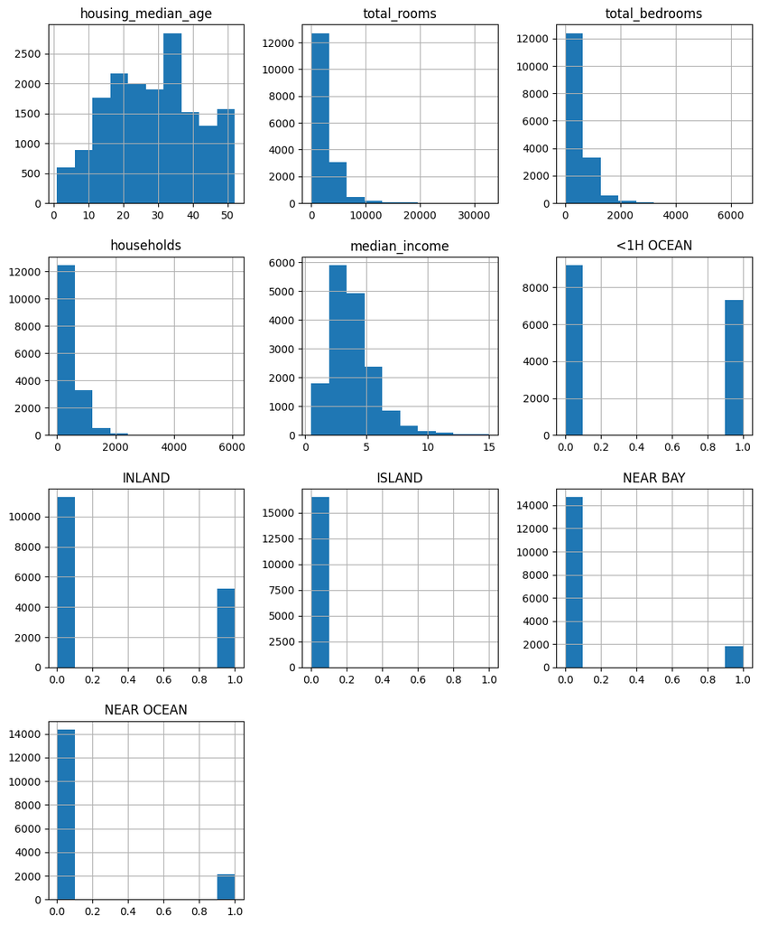

```python
# .hist() is a panadas dataframe method used to create histogram of all numeric columns

X_train.hist(bins=10, figsize=(12,15))
plt.show()
```

From the plots we have observed extreme ranges in certain columns.

```python
X_train['total_rooms'].max(), X_train['total_rooms'].min()
```

```
(32627.0, 2.0)
```

```python
X_train['total_bedrooms'].max(), X_train['total_bedrooms'].min()
```

```
(6445.0, 1.0)
```

The observation rise a conclusion that there is a possibility of outliers in some of the columns.

## Types of Scaling -

1. Min-Max Scaling - Highly impacted by outliers
2. Standard Scaling - Outlier prone

Here, we will use Standard Scaling

```python
# preparing the dataset for scaling
data = X_train.iloc[:,0:5]
```

```python
from sklearn.preprocessing import StandardScaler
```

```python
scaler = StandardScaler()
```

```python
scaled_data = scaler.fit_transform(data)
```

```python
scaled_data
```

```
array([[-1.79507596, -0.97773624, -1.09568908, -1.1356496 ,  0.19001247],
       [ 1.85553889, -0.11850059, -0.10619766, -0.13688171,  0.26931072],
       [-0.20785212, -0.42167953, -0.36070627, -0.34343319,  0.02989505],
       ...,
       [ 0.18895385, -0.55291989, -0.2441556 , -0.27806879, -0.35589721],
       [ 0.42703742, -0.23556516, -0.09192615, -0.08197562,  0.92053182],
       [-1.08082523, -0.67181359, -0.49628562, -0.52645348, -1.30490629]])
```

```python
X_train[data.columns] = scaled_data
```

```python
X_train.head()
```

|  | housing_median_age | total_rooms | total_bedrooms | households | median_income | <1H OCEAN | INLAND | ISLAND | NEAR BAY | NEAR OCEAN |
| --- | --- | --- | --- | --- | --- | --- | --- | --- | --- | --- |
| 12069 | -1.795076 | -0.977736 | -1.095689 | -1.135650 | 0.190012 | 0.0 | 1.0 | 0.0 | 0.0 | 0.0 |
| 15925 | 1.855539 | -0.118501 | -0.106198 | -0.136882 | 0.269311 | 0.0 | 0.0 | 0.0 | 1.0 | 0.0 |
| 11162 | -0.207852 | -0.421680 | -0.360706 | -0.343433 | 0.029895 | 1.0 | 0.0 | 0.0 | 0.0 | 0.0 |
| 4904 | 0.744482 | -0.888566 | -0.781716 | -0.766994 | -1.264470 | 1.0 | 0.0 | 0.0 | 0.0 | 0.0 |
| 4683 | 1.855539 | -0.122159 | 0.153068 | 0.200399 | -0.367016 | 1.0 | 0.0 | 0.0 | 0.0 | 0.0 |

## **MODELLING**

### 1. Linear Regression

```python
from sklearn.linear_model import LinearRegression
```

```python
lin_reg = LinearRegression()
```

```python
lin_reg.fit(X_train, y_train)
```

```
LinearRegression()
```

```python
y_pred = lin_reg.predict(X_train)
```

```python
y_pred
```

```
array([135193.67354099, 284842.84000137, 221327.663093  , ...,
       223801.34475746, 306772.84197213,  39704.86085579])
```

```python
y_train
```

|  | median_house_value |
| --- | --- |
| 12069 | 500001.0 |
| 15925 | 270000.0 |
| 11162 | 196100.0 |
| 4904 | 118800.0 |
| 4683 | 225000.0 |
| ... | ... |
| 13123 | 144600.0 |
| 19648 | 159400.0 |
| 9845 | 289300.0 |
| 10799 | 484600.0 |
| 2732 | 69400.0 |

16512 rows × 1 columns

**dtype:** float64

### **Visualizing the prices**

### Line Plot

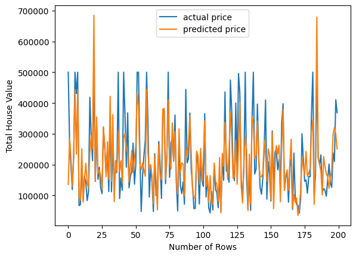

```python
plt.plot(np.array(y_train)[:200], label='actual price')
plt.plot(y_pred[:200], label = 'predicted price')
plt.legend()
plt.xlabel('Number of Rows')
plt.ylabel('Total House Value')
plt.show()
```

### Density Plot

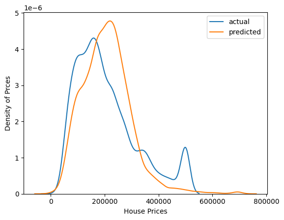

```python
sns.kdeplot(y_train, label='actual')
sns.kdeplot(y_pred, label='predicted')
plt.legend()
plt.xlabel('House Prices')
plt.ylabel('Density of Prces')
plt.show()
```

```python
from sklearn.metrics import mean_squared_error
```

```python
reg_rmse = mean_squared_error(y_train, y_pred, squared = False)
reg_rmse
```

```
71969.0811141431
```

### 2. Decision Tree

```python
from sklearn.tree import DecisionTreeRegressor
```

```python
tree_reg = DecisionTreeRegressor()
```

```python
tree_reg.fit(X_train, y_train)
```

```
DecisionTreeRegressor()
```

```python
y_pred_2 = tree_reg.predict(X_train)
```

```python
y_pred_2
```

```
array([500001., 270000., 196100., ..., 289300., 484600.,  69400.])
```

```python
y_train
```

|  | median_house_value |
| --- | --- |
| 12069 | 500001.0 |
| 15925 | 270000.0 |
| 11162 | 196100.0 |
| 4904 | 118800.0 |
| 4683 | 225000.0 |
| ... | ... |
| 13123 | 144600.0 |
| 19648 | 159400.0 |
| 9845 | 289300.0 |
| 10799 | 484600.0 |
| 2732 | 69400.0 |

16512 rows × 1 columns

**dtype:** float64

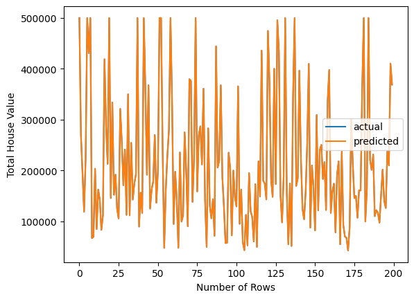

```python
plt.plot(np.array(y_train)[:200], label='actual')
plt.plot(y_pred_2[:200], label = 'predicted')
plt.legend()
plt.xlabel('Number of Rows')
plt.ylabel('Total House Value')
plt.show()
```

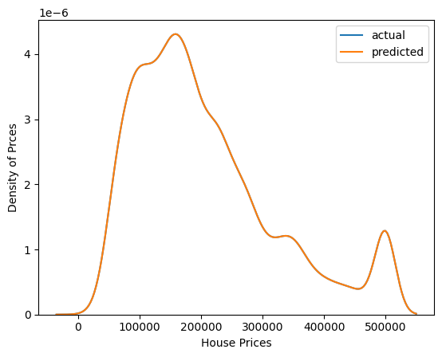

```python
sns.kdeplot(y_train, label='actual')
sns.kdeplot(y_pred_2, label='predicted')
plt.legend()
plt.xlabel('House Prices')
plt.ylabel('Density of Prces')
plt.show()
```

```python
tree_rmse = mean_squared_error(y_train, y_pred_2, squared = False)
tree_rmse
```

```
0.0
```

### 3. Random Forest

```python
from sklearn.ensemble import RandomForestRegressor
```

```python
forest_reg = RandomForestRegressor(n_estimators = 100, max_features = 10, random_state=42)
forest_reg.fit(X_train, y_train)
```

```
RandomForestRegressor(max_features=10, random_state=42)
```

```python
y_pred_3 = forest_reg.predict(X_train)
y_pred_3
```

```
array([399281.65, 312334.04, 237672.05, ..., 258890.  , 442410.07,
        70239.  ])
```

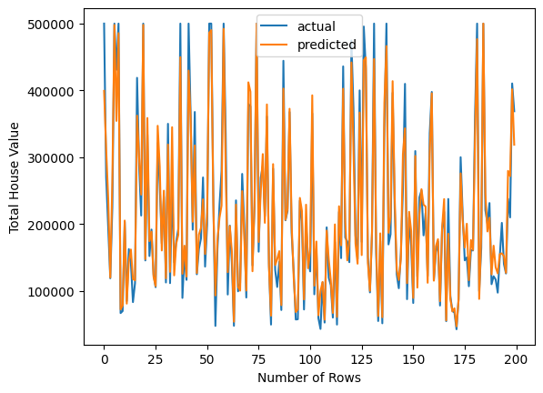

```python
plt.plot(np.array(y_train)[:200], label='actual')
plt.plot(y_pred_3[:200], label = 'predicted')
plt.legend()
plt.xlabel('Number of Rows')
plt.ylabel('Total House Value')
plt.show()
```

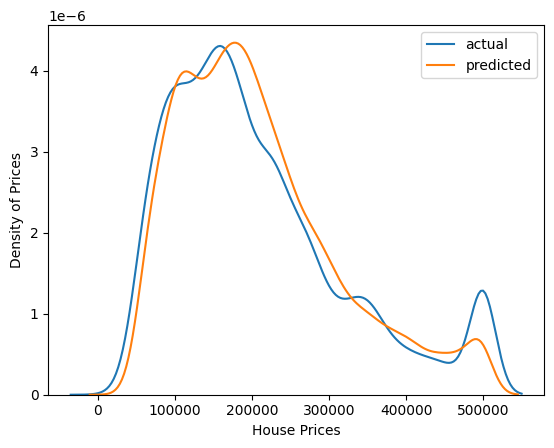

```python
sns.kdeplot(y_train, label='actual')
sns.kdeplot(y_pred_3, label='predicted')
plt.legend()
plt.xlabel('House Prices')
plt.ylabel('Density of Prices')
plt.show()
```

```python
forest_rmse = mean_squared_error(y_train, y_pred_3, squared = False)
forest_rmse
```

```
25152.605580019703
```

Applying cross validation to all the three models

```python
from sklearn.model_selection import cross_val_score
```

Linear regression

```python
lin_reg_scores = cross_val_score(lin_reg, X_train, y_train,
                         scoring="neg_mean_squared_error", cv=10)
```

```python
lin_reg_scores
```

```
array([-5.66644315e+09, -4.83734357e+09, -5.31588201e+09, -5.04566764e+09,
       -5.91604940e+09, -5.06475725e+09, -5.09682592e+09, -4.97041800e+09,
       -5.18385080e+09, -4.79989041e+09])
```

```python
lin_reg_rmse_scores = np.sqrt(-lin_reg_scores)
```

```python
lin_reg_rmse_scores
```

```
array([75275.78062855, 69551.01414766, 72910.09537563, 71032.86311229,
       76915.85925314, 71167.10789927, 71392.05779346, 70501.19147445,
       71998.96390185, 69281.24136793])
```

Decision Tree

```python
tree_reg_scores = cross_val_score(tree_reg, X_train, y_train,
                         scoring="neg_mean_squared_error", cv=10)
```

```python
tree_reg_scores
```

```
array([-8.58619883e+09, -8.36366618e+09, -8.24155648e+09, -8.81492470e+09,
       -8.96246875e+09, -8.70760777e+09, -8.10637364e+09, -7.96087011e+09,
       -8.92787652e+09, -7.33588235e+09])
```

```python
tree_reg_rmse_scores = np.sqrt(-tree_reg_scores)
```

```python
tree_reg_rmse_scores
```

```
array([92661.74416213, 91453.08185446, 90783.0186951 , 93887.83039216,
       94670.3160714 , 93314.56354791, 90035.40215646, 89223.70820813,
       94487.44108741, 85649.76563116])
```

Random Forest

```python
forest_reg_scores = cross_val_score(forest_reg, X_train, y_train,
                         scoring="neg_mean_squared_error", cv=10)
```

```python
forest_reg_scores
```

```
array([-4.74946392e+09, -4.42217479e+09, -4.64135274e+09, -4.43654547e+09,
       -5.06350404e+09, -4.33019941e+09, -4.49864435e+09, -4.54854317e+09,
       -4.57066954e+09, -3.92599617e+09])
```

```python
forest_reg_rmse_scores = np.sqrt(-forest_reg_scores)
```

```python
forest_reg_rmse_scores
```

```
array([68916.35454616, 66499.43453989, 68127.47422326, 66607.39803738,
       71158.30266217, 65804.25069996, 67071.9341653 , 67442.88824432,
       67606.72702359, 62657.7702245 ])
```

After evaluation we came to a conclusion that random forest is performing better on the train data as compared to linear regression and decision tree  
So, we can select random forest as the final model

**Joblib Library** - Used to serialize (save) a trained machine learning model to a file and later deserialize (load) it back into memory

```python
import joblib
joblib.dump(forest_reg, "final_model.pkl")
```

```
['final_model.pkl']
```

### **Note**:

### **This is the final model. Save it and use it for predictions.**

### **Do not train any other model again using test data.**

## **Test Data PreProcessing**

1. Fill the missing values of test data using the median of training data.
2. Perform scaling by applying the transform method using the previous object only. **Do not create a new object.**
3. Do not train any model again. Do not apply cross validation or any other steps. Only the final model we have prepared will be used with test data.
4. Use X_test inside final_model.predict() method for making prdictions.
5. Calculate RMSE

## **Preparing Test Data**

```python
X_test.head()
```

|  | housing_median_age | total_rooms | total_bedrooms | households | median_income | <1H OCEAN | INLAND | ISLAND | NEAR BAY | NEAR OCEAN |
| --- | --- | --- | --- | --- | --- | --- | --- | --- | --- | --- |
| 14740 | 22.0 | 2101.0 | 399.0 | 371.0 | 4.1518 | 0.0 | 0.0 | 0.0 | 0.0 | 1.0 |
| 10101 | 32.0 | 2620.0 | 398.0 | 429.0 | 5.7796 | 1.0 | 0.0 | 0.0 | 0.0 | 0.0 |
| 20566 | 29.0 | 3167.0 | 548.0 | 534.0 | 4.3487 | 0.0 | 1.0 | 0.0 | 0.0 | 0.0 |
| 2670 | 37.0 | 709.0 | 187.0 | 142.0 | 2.4511 | 0.0 | 1.0 | 0.0 | 0.0 | 0.0 |
| 15709 | 25.0 | 1637.0 | 394.0 | 379.0 | 5.0049 | 0.0 | 0.0 | 0.0 | 1.0 | 0.0 |

```python
X_test.shape
```

```
(4128, 10)
```

```python
y_test.head()
```

|  | median_house_value |
| --- | --- |
| 14740 | 136900.0 |
| 10101 | 241300.0 |
| 20566 | 200700.0 |
| 2670 | 72500.0 |
| 15709 | 460000.0 |

**dtype:** float64

Handling Missing Values of Test Data

```python
X_test.isna().sum()
```

|  | 0 |
| --- | --- |
| housing_median_age | 0 |
| total_rooms | 0 |
| total_bedrooms | 49 |
| households | 0 |
| median_income | 0 |
| <1H OCEAN | 0 |
| INLAND | 0 |
| ISLAND | 0 |
| NEAR BAY | 0 |
| NEAR OCEAN | 0 |

**dtype:** int64

Filling the missing cells with the median of training data

```python
med
```

```
434.0
```

```python
X_test.fillna(med, inplace=True)
```

```python
X_test.isna().sum()
```

|  | 0 |
| --- | --- |
| housing_median_age | 0 |
| total_rooms | 0 |
| total_bedrooms | 0 |
| households | 0 |
| median_income | 0 |
| <1H OCEAN | 0 |
| INLAND | 0 |
| ISLAND | 0 |
| NEAR BAY | 0 |
| NEAR OCEAN | 0 |

**dtype:** int64

Scaling the Test Data

```python
data = X_test.iloc[:,:5]
```

```python
data.columns
```

```
Index(['housing_median_age', 'total_rooms', 'total_bedrooms', 'households',
       'median_income'],
      dtype='object')
```

```python
scaled_test_data = scaler.transform(data)
```

```python
scaled_test_data
```

```
array([[-0.52529688, -0.24653996, -0.32740608, -0.33558946,  0.14448941],
       [ 0.26831504, -0.00920984, -0.32978466, -0.18394407,  0.99820424],
       [ 0.03023146,  0.24092422,  0.02700311,  0.09058637,  0.24775544],
       ...,
       [-1.39827   , -0.42076496, -0.45584968, -0.45324536, -0.35327491],
       [-0.84274165,  0.0452069 , -0.34167759, -0.32774573,  1.18910742],
       [ 1.85553889, -0.48478465, -0.26318428, -0.24407931, -0.28514765]])
```

```python
X_test[data.columns] = scaled_test_data
```

```python
X_test
```

|  | housing_median_age | total_rooms | total_bedrooms | households | median_income | <1H OCEAN | INLAND | ISLAND | NEAR BAY | NEAR OCEAN |
| --- | --- | --- | --- | --- | --- | --- | --- | --- | --- | --- |
| 14740 | -0.525297 | -0.246540 | -0.327406 | -0.335589 | 0.144489 | 0.0 | 0.0 | 0.0 | 0.0 | 1.0 |
| 10101 | 0.268315 | -0.009210 | -0.329785 | -0.183944 | 0.998204 | 1.0 | 0.0 | 0.0 | 0.0 | 0.0 |
| 20566 | 0.030231 | 0.240924 | 0.027003 | 0.090586 | 0.247755 | 0.0 | 1.0 | 0.0 | 0.0 | 0.0 |
| 2670 | 0.665121 | -0.883079 | -0.831666 | -0.934327 | -0.747459 | 0.0 | 1.0 | 0.0 | 0.0 | 0.0 |
| 15709 | -0.287213 | -0.458719 | -0.339299 | -0.314673 | 0.591906 | 0.0 | 0.0 | 0.0 | 1.0 | 0.0 |
| ... | ... | ... | ... | ... | ... | ... | ... | ... | ... | ... |
| 6655 | 0.347676 | 0.019142 | 0.426605 | 0.503689 | -0.731410 | 1.0 | 0.0 | 0.0 | 0.0 | 0.0 |
| 3505 | 0.585760 | -0.542860 | -0.634244 | -0.586589 | 0.266216 | 1.0 | 0.0 | 0.0 | 0.0 | 0.0 |
| 1919 | -1.398270 | -0.420765 | -0.455850 | -0.453245 | -0.353275 | 0.0 | 1.0 | 0.0 | 0.0 | 0.0 |
| 1450 | -0.842742 | 0.045207 | -0.341678 | -0.327746 | 1.189107 | 0.0 | 1.0 | 0.0 | 0.0 | 0.0 |
| 4148 | 1.855539 | -0.484785 | -0.263184 | -0.244079 | -0.285148 | 1.0 | 0.0 | 0.0 | 0.0 | 0.0 |

4128 rows × 10 columns

```python
final_model = joblib.load("final_model.pkl")
final_model
```

```
RandomForestRegressor(max_features=10, random_state=42)
```

```python
test_predictions = final_model.predict(X_test)
```

```python
test_predictions
```

```
array([218849.04, 303200.01, 149519.  , ..., 123793.  , 216449.  ,
       296909.08])
```

```python
error = mean_squared_error(y_test, test_predictions, squared=False)
```

```python
error
```

```
68189.13827790174
```

Visualizing the Actual and Predicted Test Data

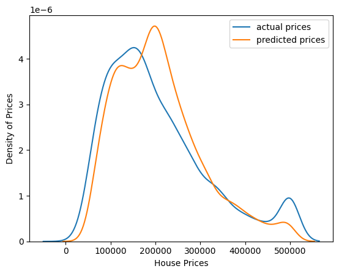

```python
sns.kdeplot(y_test, label='actual prices')
sns.kdeplot(test_predictions, label='predicted prices')
plt.legend()
plt.xlabel('House Prices')
plt.ylabel('Density of Prices')
plt.show()
```